# STA457 Assignment

Omika Dharamdasani, Student ID: 1000984483

August 05, 2016

#### Model

Fit the following transfer function noise model
$$co2_t =\alpha + \sum^s_{j} v_j \cdot gas_{t-j-b} + e_t, (1)$$
where $e_t$ is serially correlated.

#### 1. Use the ideas of prewhitening taught in class to identify b and s.

According the following figure, I identify that $b=3$ and $s=5$.

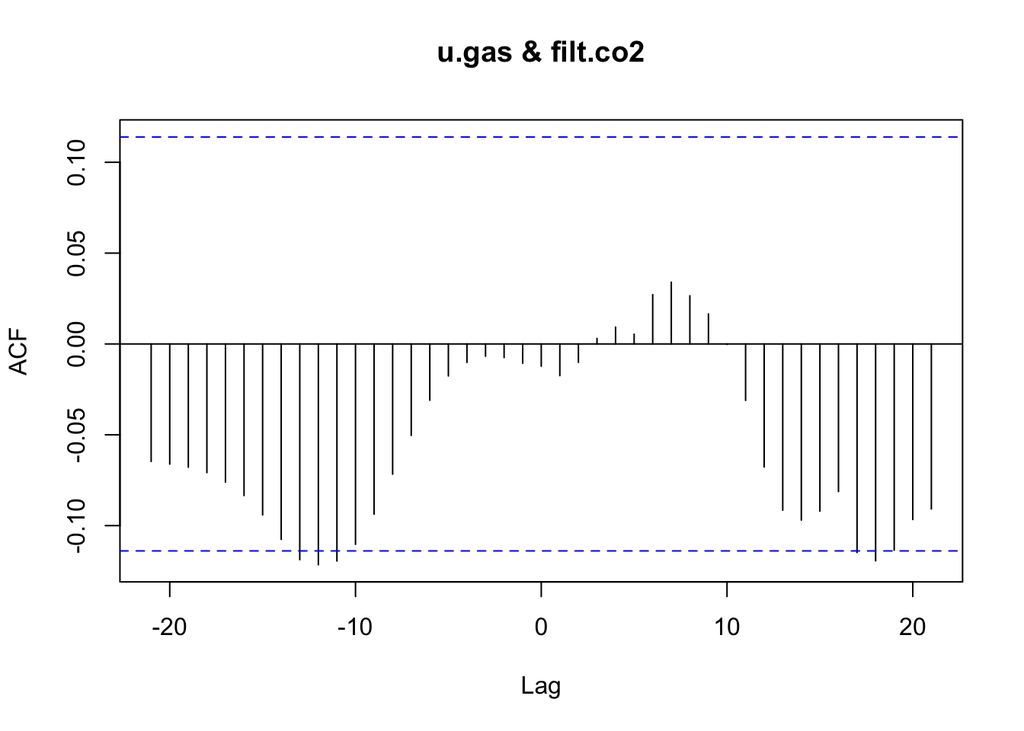

```r
# Type R codes used to produce the figure for identifying b and s
gas.ar <- arima(gas,c(5,0,0), include.mean = FALSE)
u.gas <- gas.ar$residuals
coefs <- gas.ar$coef
filt.co2 <- filter(co2, coefs, method = "recursive")
ccf <- ccf(u.gas, filt.co2, na.action=na.omit)
```

```r
ccf
```

```
##
## Autocorrelations of series 'X', by lag
##
##    -21    -20    -19    -18    -17    -16    -15    -14    -13    -12
## -0.065 -0.066 -0.068 -0.071 -0.076 -0.083 -0.094 -0.108 -0.119 -0.122
##    -11    -10     -9     -8     -7     -6     -5     -4     -3     -2
## -0.119 -0.110 -0.094 -0.072 -0.050 -0.031 -0.018 -0.010 -0.007 -0.007
##     -1      0      1      2      3      4      5      6      7      8
## -0.011 -0.012 -0.017 -0.010  0.003  0.009  0.005  0.027  0.034  0.027
##      9     10     11     12     13     14     15     16     17     18
##  0.017  0.000 -0.031 -0.068 -0.092 -0.097 -0.092 -0.081 -0.115 -0.119
##     19     20     21
## -0.114 -0.097 -0.091
```

#### 2. Fit Eqn. (1) based on your preliminary identification and R arima function

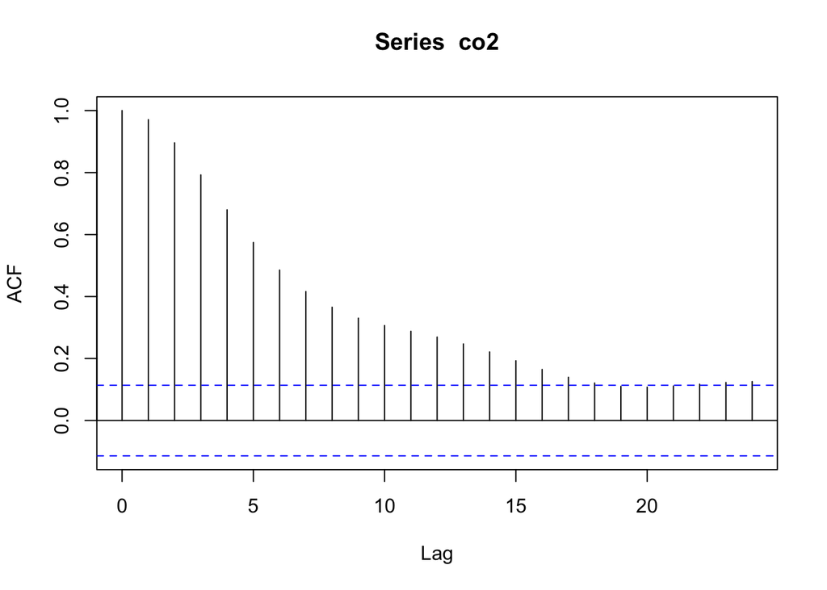

```r
# Show R codes that estimate your model and the corresponding estimation result
acf(co2)
```

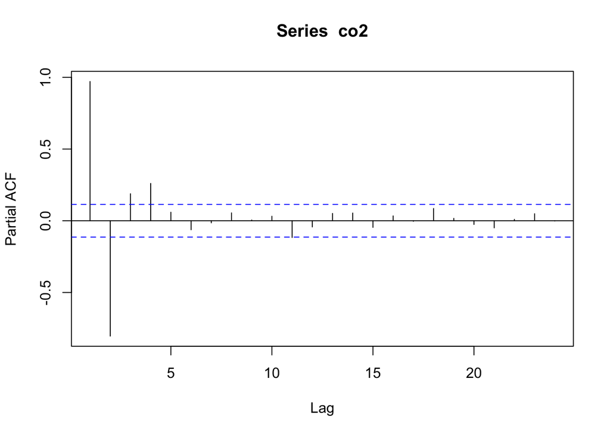

```r
pacf(co2)
# It looks like AR(4) or AR(2) could be used, but we will compare this against the model generated by auto.arima and some other models.

#install.packages("forecast")
library(forecast)
```

```r
#Using auto.arima for preliminary analysis
reg <- cbind(lag(gas,-3), lag(gas,-4), lag(gas,-5), lag(gas,-6), lag(gas,-7), lag(gas,-8))
reg <- ts(reg, start=-2, end=293)

fit1 <- auto.arima(co2, xreg=reg)
fit1
```

```
## Series: co2
## ARIMA(4,0,0) with non-zero mean
##
## Coefficients:
##          ar1      ar2      ar3     ar4  intercept  lag(gas, -3)
##       1.6901  -0.7711  -0.1024  0.1465    53.5311       -0.0363
## s.e.  0.0627   0.1196   0.1209  0.0627     0.4142        0.0875
##       lag(gas, -4)  lag(gas, -5)  lag(gas, -6)  lag(gas, -7)  lag(gas, -8)
##             0.0947        0.0898       -0.4876       -0.6428       -0.9705
## s.e.        0.0889        0.0876        0.0914        0.0944        0.0943
##
## sigma^2 estimated as 0.07302:  log likelihood=-31.16
## AIC=86.32   AICc=87.42   BIC=130.6
```

```r
#Identified as ARIMA(4,0,0). Carrying out analysis to see if a better model can be used instead:
fit2 <- arima(co2, c(2,0,0), xreg=reg, include.mean = FALSE)
fit3 <- arima(co2, c(4,0,1), xreg=reg, include.mean = FALSE)
fit4 <- arima(co2, c(3,1,2), xreg=reg, include.mean = FALSE)
fit5 <- arima(co2, c(3,1,0), xreg=reg, include.mean = FALSE)
aic1 <- fit1$aic
aic2 <- fit2$aic
aic3 <- fit3$aic
aic4 <- fit4$aic
aic5 <- fit5$aic
#Since ARIMA(3,1,2) has the highest log likelihood and lowest AIC, we will use this model.
Box.test(fit4$residuals, lag = 20, type = "Ljung-Box")
```

[output not shown]

[output not shown]

```
##
##  Box-Ljung test
##
## data:  fit4$residuals
## X-squared = 20.346, df = 20, p-value = 0.4365
```

```r
Box.test(fit4$residuals, lag = 20, type = "Box-Pierce")
```

```
##
##  Box-Pierce test
##
## data:  fit4$residuals
## X-squared = 19.318, df = 20, p-value = 0.5013
```

```r
# ARIMA (3,1,2) seems to be a good fit, because the p-values are high.
```

#### 3. Checking model adequacy of your fitted model.

The analysis of the model adequacy of the fitted model is as follows:

- e.g. My model pass the residual correlation check using the Box and Pierce and the Ljung Box test because the corresponding p-value is greater than 0.05 in both cases.

Box and Ljung: 0.9893 at lag 5 Box and Ljung: 0.5512 at lag 10 Box and Ljung: 0.4365 at lag 20

Box and Pierce: 0.9898 at lag 5 Box and Pierce: 0.5788 at lag 10 Box and Pierce: 0.5013 at lag 20

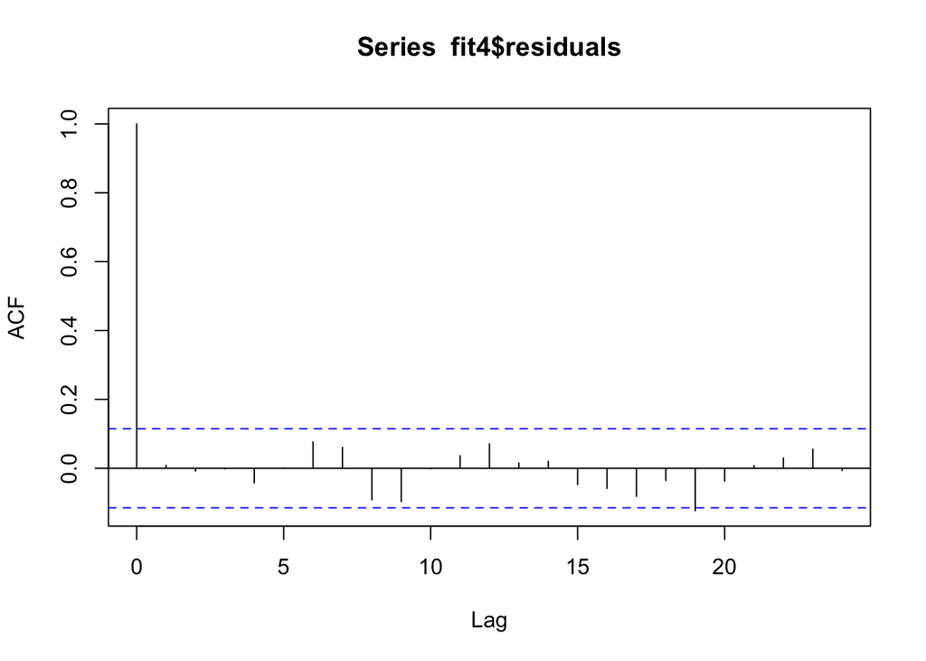

```r
# Show your R codes and results for checking model adequacy
acf(fit4$residuals, na.action = na.omit)
```

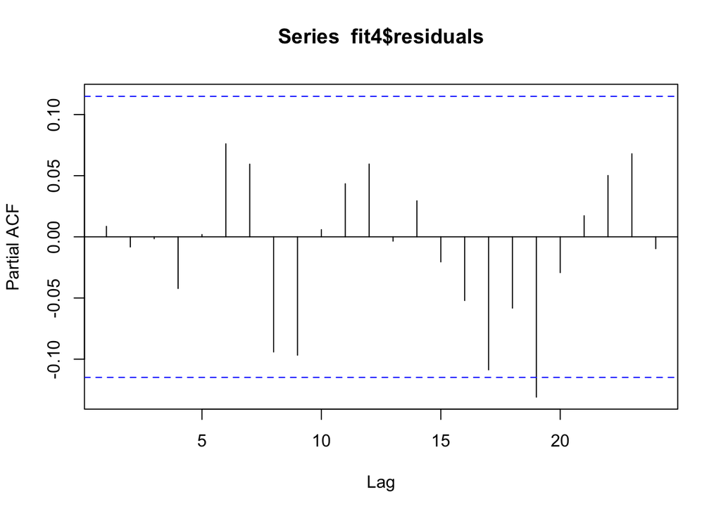

```r
pacf(fit4$residuals, na.action = na.omit)
```

```r
Box.test(fit4$residuals, lag = 20, type = "Ljung-Box")
```

```
##
##  Box-Ljung test
##
## data:  fit4$residuals
## X-squared = 20.346, df = 20, p-value = 0.4365
```

```r
Box.test(fit4$residuals, lag = 20, type = "Box-Pierce")
```

```
##
##  Box-Pierce test
##
## data:  fit4$residuals
## X-squared = 19.318, df = 20, p-value = 0.5013
```